# Final

Hwang Seong-Yun

2021 6 18

### Loading packages

```r
library(MPV)
```

### 4.16) Consider the clathrate formation data in Table B.8.

```r
data(table.b8)
force(table.b8)
```

```
##      x1  x2    y
## 1  0.00  10  7.5
## 2  0.00  50 15.0
## 3  0.00  85 22.0
## 4  0.00 110 28.6
## 5  0.00 140 31.6
## 6  0.00 170 34.0
## 7  0.00 200 35.0
## 8  0.00 230 35.5
## 9  0.00 260 36.5
## 10 0.00 290 38.5
## 11 0.00  10 12.3
## 12 0.00  30 18.0
## 13 0.00  62 20.8
## 14 0.00  90 25.7
```

[output cut: 22 more lines]

#### a. Construct a normality plot of the residuals from the full model. Does there seem to be any problem with the normality assumption?

#### b. Construct and interpret a plot of the residuals versus the predicted response.

```r
full_model1 <- lm(y~x1+x2,data=table.b8)
summary(full_model1)
```

```
##
## Call:
## lm(formula = y ~ x1 + x2, data = table.b8)
##
## Residuals:
##     Min      1Q  Median      3Q     Max
## -9.7716 -4.1656  0.0802  3.8323  8.3349
##
## Coefficients:
##              Estimate Std. Error t value Pr(>|t|)
## (Intercept) 1.109e+01  1.669e+00   6.642 1.48e-07 ***
## x1          3.501e+02  3.968e+01   8.823 3.38e-10 ***
## x2          1.089e-01  9.983e-03  10.912 1.74e-12 ***
## ---
## Signif. codes:  0 '***' 0.001 '**' 0.01 '*' 0.05 '.' 0.1 ' ' 1
##
## Residual standard error: 4.782 on 33 degrees of freedom
## Multiple R-squared:  0.8415, Adjusted R-squared:  0.8319
## F-statistic:  87.6 on 2 and 33 DF,  p-value: 6.316e-14
```

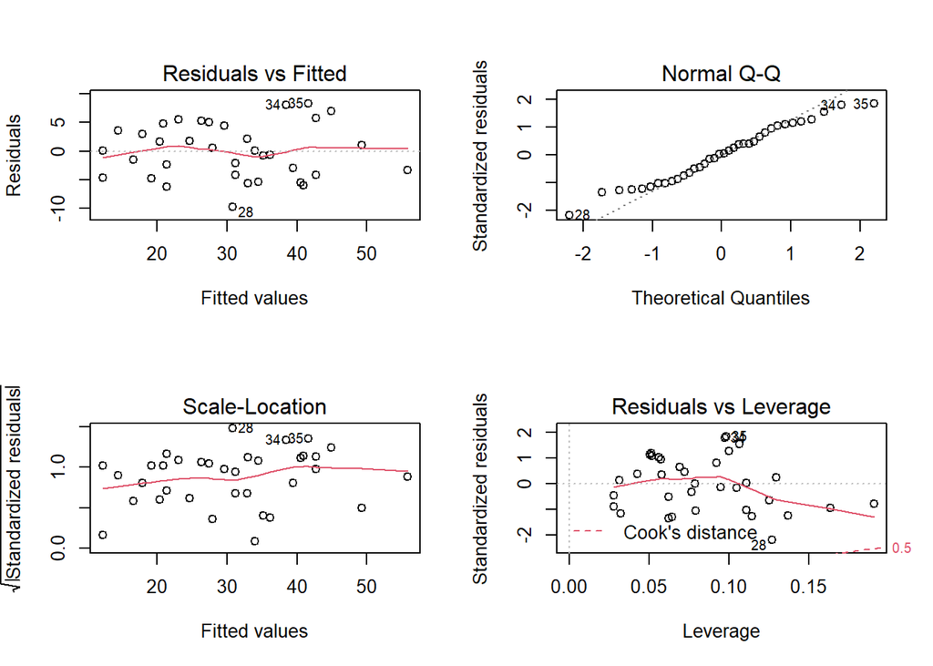

```r
par(mfrow=c(2,2))
plot(full_model1)
```

```r
par(mfrow=c(1,1))
```

- full model에 대한 검증 plot을 그려본 결과, Normal Q-Q plot에서 정규성이 의심되는 특징(이론적 분위수를 나타내는 직선에서 떨어져 있는 점 존재)을 보이고 있고, 잔차그림을 통해서 이상치(outlier)도 존재하고 있는 것으로 판단된다.
- 또한 Residuals versus Fitted values plot을 살펴봤을 때 붉은색의 선이 평평하지 않고 약간 증가하고 있는 경향이 있는 것으로 보여지고 있기 때문에 독립성의 가정을 의심해볼 수 있겠다. 이 외에 등분산성의 경우는 plot의 퍼짐 정도가 그래도 고른 편이기 때문에 가정을 크게 위배하지는 않는다고 여겨진다.

### 5.10) Consider the pressure drop data in Table B.9.

```r
data(table.b9)
force(table.b9)
```

```
##      x1     x2   x3    x4    y
## 1  2.14  10.00 0.34 1.000 28.9
## 2  4.14  10.00 0.34 1.000 31.0
## 3  8.15  10.00 0.34 1.000 26.4
## 4  2.14  10.00 0.34 0.246 27.2
## 5  4.14  10.00 0.34 0.379 26.1
## 6  8.15  10.00 0.34 0.474 23.2
## 7  2.14  10.00 0.34 0.141 19.7
## 8  4.14  10.00 0.34 0.234 22.1
## 9  8.15  10.00 0.34 0.311 22.8
## 10 2.14  10.00 0.34 0.076 29.2
## 11 4.14  10.00 0.34 0.132 23.6
## 12 8.15  10.00 0.34 0.184 23.6
## 13 2.14   2.63 0.34 0.679 24.2
## 14 4.14   2.63 0.34 0.804 22.1
```

[output cut: 48 more lines]

#### a. Perform a thorough residual analysis of these data.

```r
full_model2 <- lm(y~x1+x2+x3+x4,data=table.b9)
summary(full_model2)
```

```
##
## Call:
## lm(formula = y ~ x1 + x2 + x3 + x4, data = table.b9)
##
## Residuals:
##     Min      1Q  Median      3Q     Max
## -9.9958 -3.3092 -0.2419  3.3924 10.5668
##
## Coefficients:
##             Estimate Std. Error t value Pr(>|t|)
## (Intercept)  5.89453    4.32508   1.363  0.17828
## x1          -0.47790    0.34002  -1.406  0.16530
## x2           0.18271    0.01718  10.633 3.78e-15 ***
## x3          35.40284   11.09960   3.190  0.00232 **
## x4           5.84391    2.90978   2.008  0.04935 *
## ---
## Signif. codes:  0 '***' 0.001 '**' 0.01 '*' 0.05 '.' 0.1 ' ' 1
##
## Residual standard error: 5.014 on 57 degrees of freedom
## Multiple R-squared:  0.6914, Adjusted R-squared:  0.6697
## F-statistic: 31.92 on 4 and 57 DF,  p-value: 5.818e-14
```

```r
library(MASS)
fit.step <- stepAIC(full_model2,direction="both",trace=TRUE)
```

```
## Start:  AIC=204.7
## y ~ x1 + x2 + x3 + x4
##
##        Df Sum of Sq    RSS    AIC
## <none>              1432.8 204.69
## - x1    1     49.66 1482.4 204.81
## - x4    1    101.39 1534.2 206.93
## - x3    1    255.72 1688.5 212.88
## - x2    1   2841.93 4274.7 270.47
```

```r
summary(fit.step)
```

```
##
## Call:
## lm(formula = y ~ x1 + x2 + x3 + x4, data = table.b9)
##
## Residuals:
##     Min      1Q  Median      3Q     Max
## -9.9958 -3.3092 -0.2419  3.3924 10.5668
##
## Coefficients:
##             Estimate Std. Error t value Pr(>|t|)
## (Intercept)  5.89453    4.32508   1.363  0.17828
## x1          -0.47790    0.34002  -1.406  0.16530
## x2           0.18271    0.01718  10.633 3.78e-15 ***
## x3          35.40284   11.09960   3.190  0.00232 **
## x4           5.84391    2.90978   2.008  0.04935 *
## ---
## Signif. codes:  0 '***' 0.001 '**' 0.01 '*' 0.05 '.' 0.1 ' ' 1
##
## Residual standard error: 5.014 on 57 degrees of freedom
## Multiple R-squared:  0.6914, Adjusted R-squared:  0.6697
## F-statistic: 31.92 on 4 and 57 DF,  p-value: 5.818e-14
```

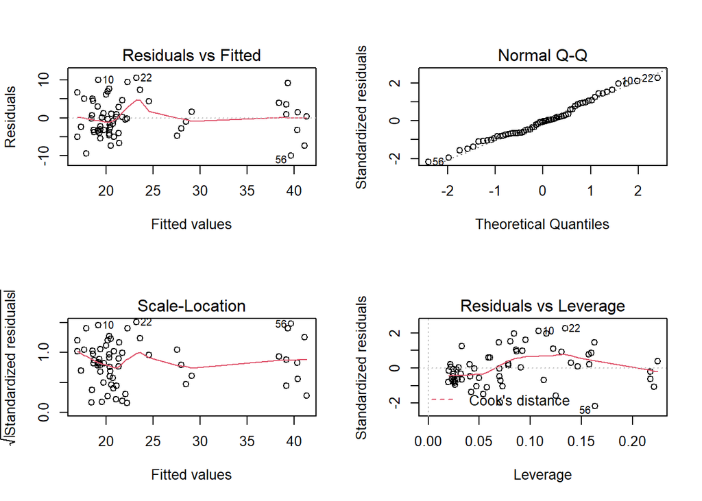

```r
par(mfrow=c(2,2))
plot(fit.step)
```

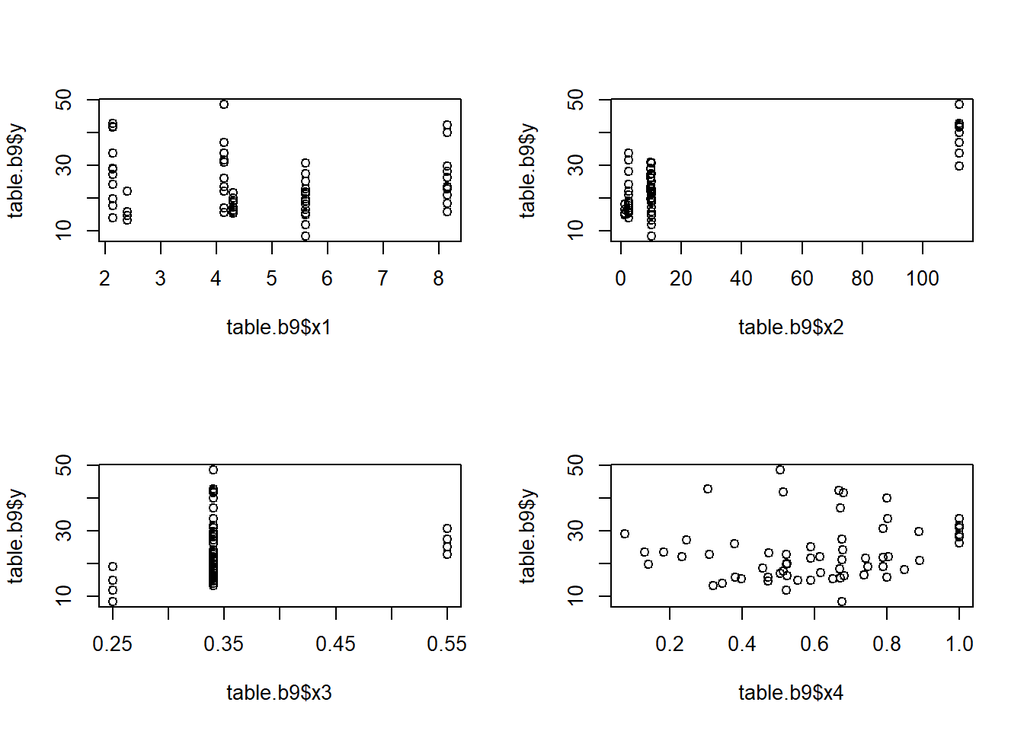

```r
par(mfrow=c(1,1))
par(mfrow=c(2,2))
plot(table.b9$x1,table.b9$y)
plot(table.b9$x2,table.b9$y)
plot(table.b9$x3,table.b9$y)
plot(table.b9$x4,table.b9$y)
```

```r
par(mfrow=c(1,1))
```

- full model에 대하여 AIC 기준을 통해 변수를 선택한 모형인 fit.step에 대한 잔차 plot을 통해 잔차의 분포가 고르지 않고 붉은색 선이 곡선모양을 나타내며 물결치고 있는 것으로 보아 등분산성 및 독립성의 가정이 의심된다. 이에 따라 Boxcox transformation을 적용해보도록 한다.
- 그리고 반응변수 y와 4개의 설명변수에 대한 plot을 통해 변수 x1,x2,x3에 대해서는 log 변환을, 변수 x4에 대해서는 square root 변환을 적용하여 분산을 좀 더 안정화시킬 수 있을 것이라 보여진다.

#### b. Identify the most appropriate transformation for these data. Fit the transformation model and repeat the residual analysis.

```r
library(EnvStats)
```

```r
(l1 <- boxcox(fit.step,optimize=T))
```

```
## $lambda
## [1] 0.5663565
##
## $objective
## [1] 0.9918125
##
## $objective.name
## [1] "PPCC"
##
## $optimize
## [1] TRUE
##
## $optimize.bounds
## lower upper
##    -2     2
##
## $eps
## [1] 2.220446e-16
##
## $lm.obj
##
## Call:
## lm(formula = y ~ x1 + x2 + x3 + x4, data = table.b9, y = TRUE,
##     qr = TRUE)
##
## Coefficients:
## (Intercept)           x1           x2           x3           x4
##      5.8945      -0.4779       0.1827      35.4028       5.8439
##
##
## $sample.size
## [1] 62
##
## $data.name
## [1] "fit.step"
##
## attr(,"class")
## [1] "boxcoxLm"
```

```r
table.b9$y_trans <- (table.b9$y^l1$lambda-1)/l1$lambda
fit.boxcox <- lm(y_trans~log(x1)+log(x2)+log(x3)+sqrt(x4),data=table.b9)
summary(fit.boxcox)
```

```
##
## Call:
## lm(formula = y_trans ~ log(x1) + log(x2) + log(x3) + sqrt(x4),
##     data = table.b9)
##
## Residuals:
##     Min      1Q  Median      3Q     Max
## -3.4912 -0.8029 -0.0908  0.8536  2.7987
##
## Coefficients:
##             Estimate Std. Error t value Pr(>|t|)
## (Intercept)   8.7866     1.6413   5.353 1.60e-06 ***
## log(x1)      -0.6753     0.4165  -1.621  0.11050
## log(x2)       1.1909     0.1391   8.559 8.18e-12 ***
## log(x3)       3.8442     1.2105   3.176  0.00241 **
## sqrt(x4)      3.1250     1.1313   2.762  0.00771 **
## ---
## Signif. codes:  0 '***' 0.001 '**' 0.01 '*' 0.05 '.' 0.1 ' ' 1
##
## Residual standard error: 1.376 on 57 degrees of freedom
## Multiple R-squared:  0.6123, Adjusted R-squared:  0.5851
## F-statistic: 22.51 on 4 and 57 DF,  p-value: 3.449e-11
```

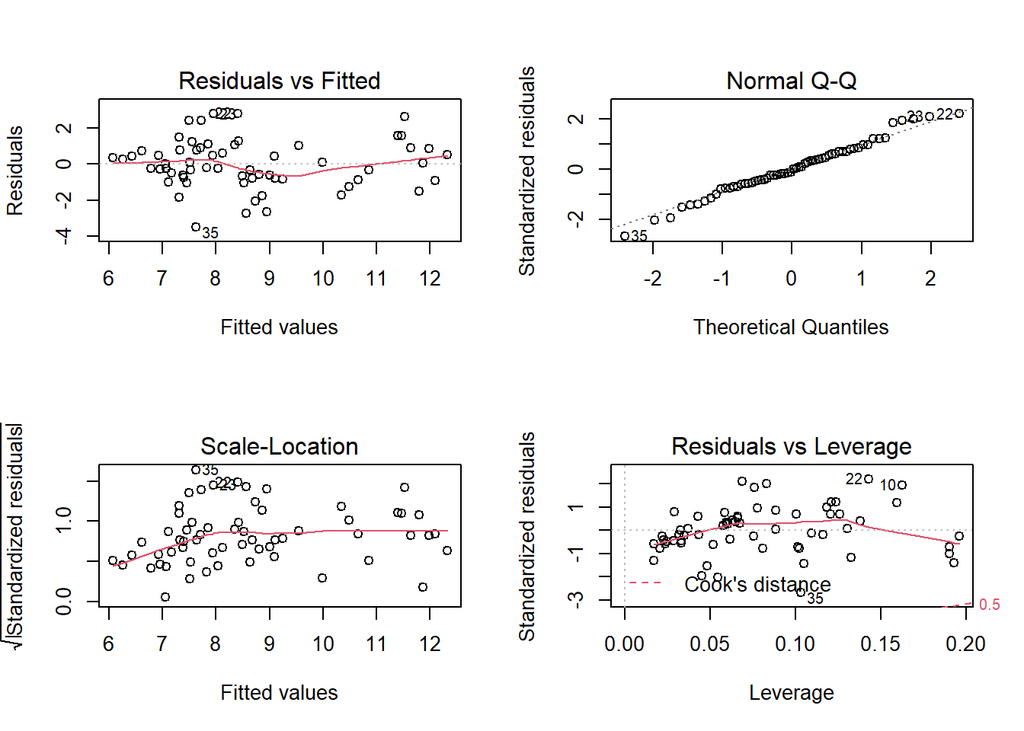

```r
par(mfrow=c(2,2))
plot(fit.boxcox)
```

```r
par(mfrow=c(1,1))
```

- 변환을 통해 모형의 안정성이 어느정도 확보된 것으로 보인다. 하지만, 이상치가 여전히 존재하는 것을 확인할 수 있고, 이에 대해서는 해당변수들에 대한 사전지식을 통해 또다른 해결점을 찾아야할 것으로 보여진다.